# Final Exam 2021 (Answer Key)

Joe Ornstein

November 30, 2021

## Problem 1: Load the Datasets

First, we’ll load the surveillance data (`surv_data.dta`) and the baseline symptoms datasets (`union_baseline_blood_stats.dta`).

```r
library(tidyverse)
library(readstata13)
library(here)

baseline <- read.dta13(
  here(
    'problem-sets/hidden/union_baseline_blood_stats.dta'
    )
)


surv <- read.dta13(
  here(
    'problem-sets/hidden/surv_data.dta'
    )
)
```

## Problem 2: Causal Inference

The great advantage of a randomized experiment here is that there’s no reason to believe that places with effective public health campaigns would be similar to places without public health campaigns. Your list of confounders may vary, but I would worry in particular that villages with public health campaigns are closer to big cities, or that such campaigns would be specifically targeted at places that are struggling with the pandemic. These are exactly the places where you expect to observe more mask wearing anyway.

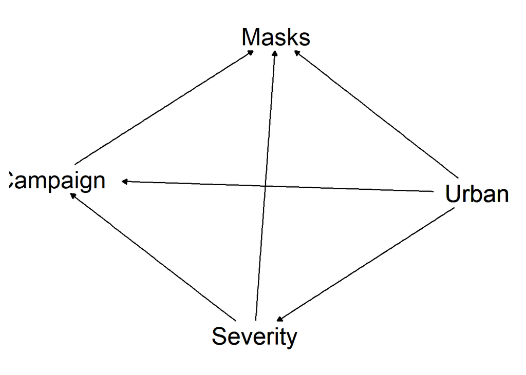

```r
library(dagitty)
library(ggdag)

dag <- dagify(Masks ~ Severity + Urban +
         Campaign,
       Campaign ~ Severity + Urban,
       Severity ~ Urban)

ggdag_classic(dag) +
  theme_dag()
```

We could condition on those variables in a linear model, but a more compelling research design is to condition on them by assigning the public health campaign at random.

## Problem 3: Balance Test

Did the randomization help? One way to gain confidence that it did is to compare some observable confounders, like the baseline prevalence of COVID.

```r
baseline %>%
  group_by(treatment) %>%
  summarize(pct_symptomatic = mean(prop_posXsymp_base),
            num_villages = n())
```

```
## # A tibble: 2 x 3
##   treatment pct_symptomatic num_villages
##       <int>           <dbl>        <int>
## 1         0        0.000285          286
## 2         1        0.000239          286
```

```r
t.test(prop_posXsymp_base ~ treatment,
       data = baseline)
```

```
##
##  Welch Two Sample t-test
##
## data:  prop_posXsymp_base by treatment
## t = 0.60038, df = 534.12, p-value = 0.5485
## alternative hypothesis: true difference in means is not equal to 0
## 95 percent confidence interval:
##  -0.0001027885  0.0001932727
## sample estimates:
## mean in group 0 mean in group 1
##    0.0002847281    0.0002394860
```

Baseline prevalence is extremely low – only 82 individuals with COVID-19 symptoms across all 572 villages – and there appears to be no significant difference between treated and control villages. This suggests that the experiment has successfully conditioned on that potential confounder.

## Problem 4: Wrangle the Surveillance Data

Next, we’ll tidy up the surveillance data and compare the treatment and control villages. Because each row in `surv` contains multiple observations spread across a bunch of columns, we need to pivot those columns so that each row is a unique observation.

```r
mask_outcomes <- surv %>%
    # keep only the 572 villages with complete baseline data
  filter(union %in% baseline$union) %>%
  # drop the baseline (week_gen == 1) and post-intervention data (week_gen 7 or 8)
  filter(week_gen > 1, week_gen < 7) %>%
  # select district, union, treatment status, and mask variables (mask_a1 - mask_a1249)
  select(district, union, treatment, pairID, contains('mask_a')) %>%
  # pivot the mask variables to long format
  pivot_longer(cols = mask_a1:mask_a1249,
               values_to = 'mask',
               names_to = 'observation_number') %>%
  # remove the rows with missing mask observations
  filter(!is.na(mask)) %>%
  # code any proper mask wearing as a 1
  mutate(proper_mask_wearing = if_else(mask %in% c('Wearing a project mask that covers the nose and mouth', 'Wearing a non-project mask or face covering that covers the nose and mouth'), 1, 0))

head(mask_outcomes)
```

```
## # A tibble: 6 x 7
##   district   union treatment pairID observation_num~ mask       proper_mask_wea~
##   <fct>      <dbl>     <int>  <int> <chr>            <fct>                 <dbl>
## 1 Brahaman~ 2.01e6         0      3 mask_a1          Wearing a~                1
## 2 Brahaman~ 2.01e6         0      3 mask_a2          Wearing a~                1
## 3 Brahaman~ 2.01e6         0      3 mask_a3          Wearing a~                1
## 4 Brahaman~ 2.01e6         0      3 mask_a4          Wearing a~                1
## 5 Brahaman~ 2.01e6         0      3 mask_a5          Wearing a~                1
## 6 Brahaman~ 2.01e6         0      3 mask_a6          Wearing a~                1
```

```r
# now group by village
village_mask_outcomes <- mask_outcomes %>%
  group_by(district, union, pairID, treatment) %>%
  summarize(pct_proper = sum(proper_mask_wearing) / n() * 100)

head(village_mask_outcomes)
```

```
## # A tibble: 6 x 5
## # Groups:   district, union, pairID [6]
##   district        union pairID treatment pct_proper
##   <fct>           <dbl>  <int>     <int>      <dbl>
## 1 Brahamanbaria 2012102      3         0      25.3
## 2 Brahamanbaria 2012103      2         0       2.77
## 3 Brahamanbaria 2012104      2         1      94.8
## 4 Brahamanbaria 2012105      3         1      52.9
## 5 Chittagong    2015106      4         0      39.2
## 6 Chittagong    2015107      4         1      66.9
```

## Problem 5: Merge

As in the authors’ analysis, we’ll only keep the villages that had complete data at baseline, and merge baseline symptoms data into our new village-level dataset.

```r
# merge village level mask outcomes
# with baseline symptoms data
d <- left_join(village_mask_outcomes,
               baseline,
               by = c('union', 'treatment',
                      'pairID'))
```

## Problem 6: Visualize

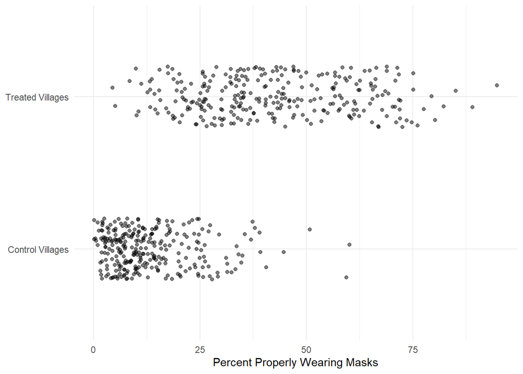

```r
ggplot(data = d,
       mapping = aes(x=pct_proper, y=ifelse(treatment == 0,
                                            'Control Villages',
                                            'Treated Villages'))) +
  geom_jitter(height = 0.2, width = 0, alpha = 0.5) +
  theme_minimal() +
  labs(x = 'Percent Properly Wearing Masks',
       y = NULL)
```

## Problem 7: Hypothesis Test

```r
mask_outcomes %>%
  group_by(treatment) %>%
  summarize(pct_proper = mean(proper_mask_wearing) * 100,
            num_observations = n())
```

```
## # A tibble: 2 x 3
##   treatment pct_proper num_observations
##       <int>      <dbl>            <int>
## 1         0       13.3           806547
## 2         1       42.3           797715
```

```r
t.test(pct_proper ~ treatment, data = d)
```

```
##
##  Welch Two Sample t-test
##
## data:  pct_proper by treatment
## t = -23.541, df = 446.73, p-value < 2.2e-16
## alternative hypothesis: true difference in means is not equal to 0
## 95 percent confidence interval:
##  -31.51468 -26.65827
## sample estimates:
## mean in group 0 mean in group 1
##        13.19873        42.28520
```

## Problem 8: Linear Model

```r
lm1 <- lm(pct_proper ~ treatment + prop_posXsymp_base + factor(pairID),
          data = d)

lm1$coefficients['treatment']
```

```
## treatment
##  29.12612
```

```r
confint(lm1)['treatment',]
```

```
##    2.5 %   97.5 %
## 26.99840 31.25385
```

Even when compared to their paired control villages and conditioning on baseline symptom rate, the estimated average treatment effect remains roughly 29%.

## Problem 9: Bonus Fun!

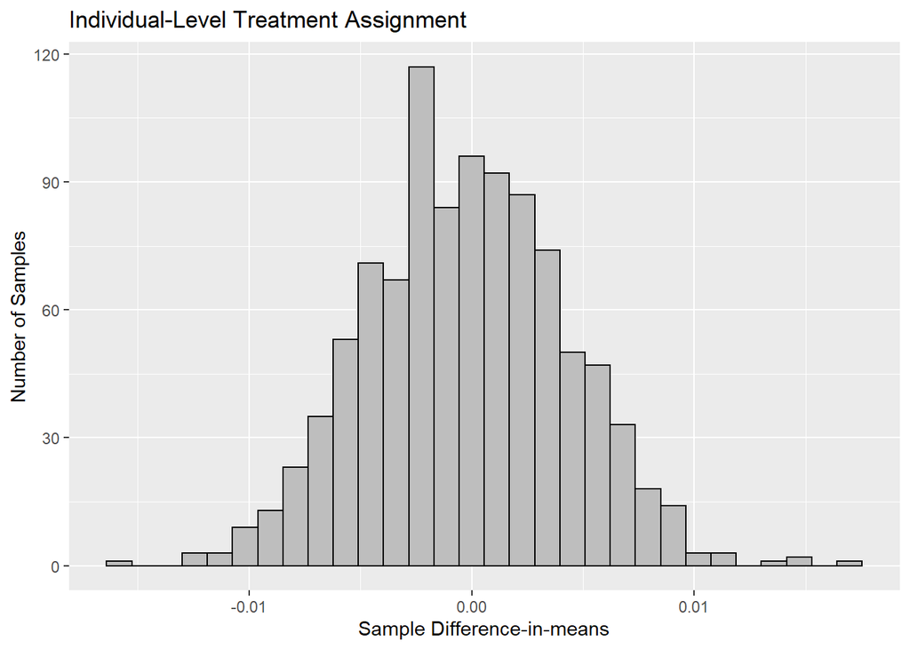

```r
potential_outcomes <- read_csv(here('problem-sets/hidden/potential-outcomes.csv'))

# sampling distribution, individual treatment assignment
get_estimate_individual <- function(sample_size = 50000){

  sample_data <- potential_outcomes %>%
    # draw 50000 individuals
    slice_sample(n = sample_size) %>%
    # randomly assign treatment at the individual level
    mutate(treatment = sample(c(0,1),
                              size = sample_size,
                              replace = TRUE)) %>%
    # observe potential outcomes based on treatment
    mutate(Y = if_else(treatment == 1, Y1, Y0))

  # return difference in means
  mean(sample_data$Y[sample_data$treatment == 1]) -
    mean(sample_data$Y[sample_data$treatment == 0])

}

# a little if-else statement so it doesn't resample every time I knit my PDF.
recompute <- FALSE
if (recompute){
  sampling_distribution_individual <- replicate(1000,
                                                get_estimate_individual())

  save(sampling_distribution_individual,
       file = 'sampling_distribution_individual.RData')

} else{
  load('sampling_distribution_individual.RData')
}


# sampling distribution, village treatment assignment
get_estimate_village <- function(sample_size = 100){

  # draw 100 villages
  villages <- potential_outcomes %>%
    select(village_id) %>%
    unique %>%
    slice_sample(n = sample_size) %>%
    # randomly assign treatment at the village level
    mutate(treatment = sample(c(0,1),
                              size = sample_size,
                              replace = TRUE))

  # draw the individual-level sample
  sample_data <- potential_outcomes %>%
    # keep only the villages assigned to treatment or control
    filter(village_id %in% villages$village_id) %>%
    # merge treatment assignment into the individual data
    left_join(villages, by = 'village_id') %>%
    # observe potential outcomes based on treatment
    mutate(Y = if_else(treatment == 1, Y1, Y0))

  # return difference in means
  mean(sample_data$Y[sample_data$treatment == 1]) -
    mean(sample_data$Y[sample_data$treatment == 0])

}

if (recompute){
  sampling_distribution_village <- replicate(1000,
                                    get_estimate_village())

  save(sampling_distribution_village,
       file = 'sampling_distribution_village.RData')

} else{
  load('sampling_distribution_village.RData')
}

# plot the sampling distributions
ggplot(mapping = aes(x=sampling_distribution_individual)) +
  geom_histogram(color = 'black', fill = 'gray') +
  labs(title = 'Individual-Level Treatment Assignment',
       x = 'Sample Difference-in-means',
       y = 'Number of Samples')
```

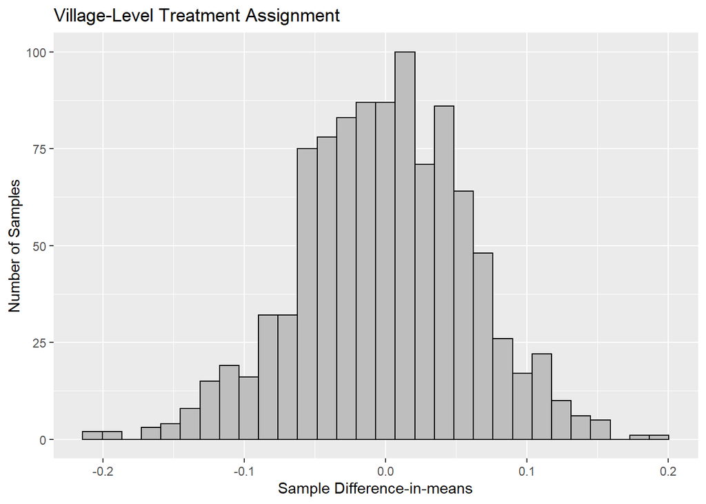

```r
ggplot(mapping = aes(x=sampling_distribution_village)) +
  geom_histogram(color = 'black', fill = 'gray') +
  labs(title = 'Village-Level Treatment Assignment',
       x = 'Sample Difference-in-means',
       y = 'Number of Samples')
```

```r
# compare the standard errors
sd(sampling_distribution_individual)
```

```
## [1] 0.004465018
```

```r
sd(sampling_distribution_village)
```

```
## [1] 0.06031888
```

## Addendum: Baseline Mask-Wearing

I figured out where to find baseline mask-wearing rates. It’s in the surveillance data! All the observations with `week_gen == 1` are at baseline, before the intervention takes place. The following is bonus, *bonus* fun.

```r
# get baseline mask-wearing by village
baseline_masking <- surv %>%
    # keep only the 572 villages with complete baseline data
  filter(union %in% baseline$union) %>%
  # keep only the baseline observations
  filter(week_gen ==1) %>%
  # select district, union, treatment status, and mask variables (mask_a1 - mask_a1249)
  select(district, union, treatment, pairID, contains('mask_a')) %>%
  # pivot the mask variables to long format
  pivot_longer(cols = mask_a1:mask_a1249,
               values_to = 'mask',
               names_to = 'observation_number') %>%
  # remove the rows with missing mask observations
  filter(!is.na(mask)) %>%
  # code any proper mask wearing as a 1
  mutate(proper_mask_wearing = if_else(mask %in% c('Wearing a project mask that covers the nose and mouth', 'Wearing a non-project mask or face covering that covers the nose and mouth'), 1, 0))

head(baseline_masking)
```

```
## # A tibble: 6 x 7
##   district   union treatment pairID observation_num~ mask       proper_mask_wea~
##   <fct>      <dbl>     <int>  <int> <chr>            <fct>                 <dbl>
## 1 Brahaman~ 2.01e6         0      3 mask_a1          Not weari~                0
## 2 Brahaman~ 2.01e6         0      3 mask_a2          Not weari~                0
## 3 Brahaman~ 2.01e6         0      3 mask_a3          Not weari~                0
## 4 Brahaman~ 2.01e6         0      3 mask_a4          Wearing a~                1
## 5 Brahaman~ 2.01e6         0      3 mask_a5          Not weari~                0
## 6 Brahaman~ 2.01e6         0      3 mask_a6          Wearing a~                0
```

```r
# now group by village
village_baseline_masking <- baseline_masking %>%
  group_by(district, union, pairID, treatment) %>%
  summarize(pct_proper_baseline = sum(proper_mask_wearing) / n() * 100,
            total_baseline_observations = n())

head(village_baseline_masking)
```

```
## # A tibble: 6 x 6
## # Groups:   district, union, pairID [6]
##   district      union pairID treatment pct_proper_baseli~ total_baseline_observ~
##   <fct>         <dbl>  <int>     <int>              <dbl>                  <int>
## 1 Brahamanba~ 2012102      3         0              16.5                     485
## 2 Brahamanba~ 2012103      2         0               5.41                    481
## 3 Brahamanba~ 2012104      2         1               1.55                    452
## 4 Brahamanba~ 2012105      3         1              25.0                     559
## 5 Chittagong  2015106      4         0              35.9                     781
## 6 Chittagong  2015107      4         1              55.6                    1155
```

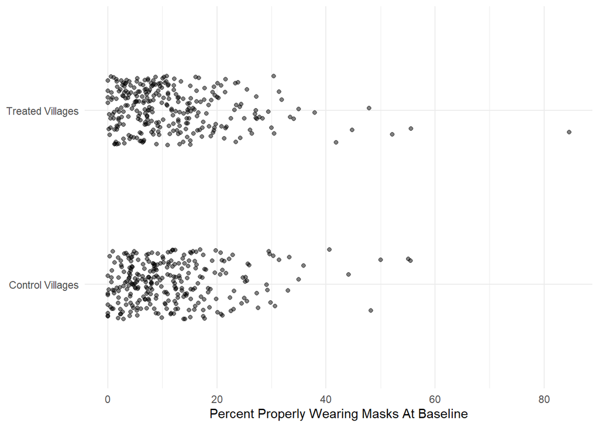

```r
# visualize difference in masking at baseline
ggplot(data = village_baseline_masking,
       mapping = aes(x=pct_proper_baseline, y=ifelse(treatment == 0,
                                            'Control Villages',
                                            'Treated Villages'))) +
  geom_jitter(height = 0.2, width = 0, alpha = 0.5) +
  theme_minimal() +
  labs(x = 'Percent Properly Wearing Masks At Baseline',
       y = NULL)
```

```r
# merge with village-level dataset
d <- left_join(d, village_baseline_masking,
               by = c('district', 'union',
                      'pairID', 'treatment'))

lm2 <- lm(pct_proper ~ treatment + prop_posXsymp_base + pct_proper_baseline + factor(pairID),
          data = d)

coef(lm2)['treatment']
```

```
## treatment
##  29.11549
```

```r
confint(lm2)['treatment',]
```

```
##    2.5 %   97.5 %
## 26.98881 31.24218
```